# Effect Sizes

University of San Francisco, MSMI-603

Matt Meister

2022-12-31

## Thus far

So far, we have learned about:

- Means
- Variance
- Statistical significance

*(among other things)*

## Thus far

We’ve learned to say things like:

- The difference in `clicking` between group A and B is 2%
  - And this is significant because *p < .001*
- With every $10,000 increase in `income`, customers spend $25 more in our stores
  - And this slope is significantly different from 0 because *p = .02*
- Customers who are 25-34 are more interested in our product than those who are 35-44
  - $M_{25-34}$ = 4.85/6
  - $M_{25-34}$ = 4.32/6
  - This might be due to chance, as *p = .09*

## Thus far

Have we learned to say things like:

- The difference in `clicking` between group A and B is 2%
  - This is a **big difference**?
- With every $10,000 increase in `income`, customers spend $25 more in our stores
  - This is a **big difference**?
- Customers who are 25-34 are more interested in our product than those who are 35-44
  - $M_{25-34}$ = 4.85/6
  - $M_{25-34}$ = 4.32/6
  - This is a **big difference**?

## Thus far

No!

For the clearest example, let’s focus on the third:

- *The one that uses a 0-6 scale*
- What is a difference of .53 on a 0-6 scale?
  - Is that big?
  - Does it matter in this context?
  - **To answer this, we are going to learn about effect sizes**

## Effect sizes

Effect sizes put our results into a standard format.

- They do not tell us if our result is statistically significant or not.
  - We use them after that
- They tell us about how **big** our results are
  - Again, in a standardized format

## Effect sizes

Effect sizes put our results into a standard format.

There are two kinds of effect sizes, broadly:

- Standardized differences
  - These give us a standardized way to say whether the difference between groups is **big**
- Variance explained
  - These tell us whether some variable explains **a lot** or **a little** of our DV

## Effect sizes

Effect sizes put our results into a standard format.

We will learn two today

- Standardized differences
  - Cohen’s d
    - $\frac{(M_A - M_B)}{SD_{AB}}$
- Variance explained
  - $R^2$
    - $1 - \frac{SSR}{n - p - 1} \div \frac{SST}{n - 1}$
  - These tell us whether some variable explains **a lot** or **a little** of our DV

## Cohen’s d

$\frac{(M_A - M_B)}{SD_{AB}}$

- $M_A$: Mean of group A
- $M_B$: Mean of group B
- $SD_{AB}$: Pooled standard deviation
  - Averaging the standard deviation is fine

This tells us how large the difference between groups is in terms of total variance in the data.

## Cohen’s d - Examples

Heights of men and women in the US:

*Are men and women different heights on average?*

- $M_{Male}$ = 69 inches
- $M_{Female}$ = 64 inches
- $SD_{Height}$ = 2.75 inches
- Cohen’s d?
  - 1.81

## Cohen’s d - Examples

Heights of men and women in the US:

- Cohen’s d = 1.81

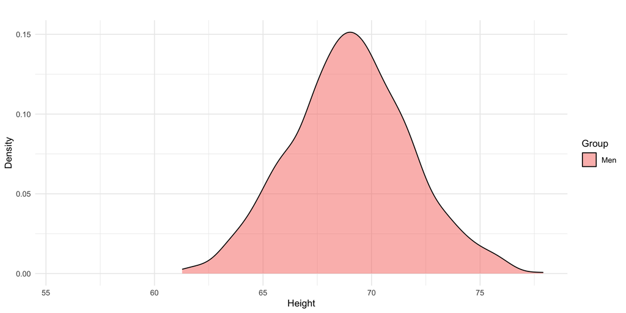

## Cohen’s d - Examples

Heights of men and women in the US:

- Cohen’s d = 1.81

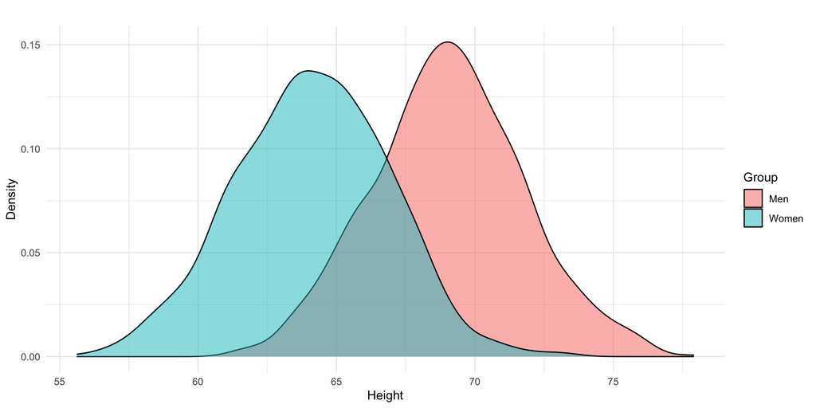

## Cohen’s d - Examples

*Are people are more aggressive toward individuals who have provoked them?*

- $M_{Provoked}$ = 8.232/10
- $M_{Unprovoked}$ = 4.4/10
- $SD_{Aggression}$ = 3.22
- Cohen’s d?
  - 1.19

## Cohen’s d - Examples

*Are people are more aggressive toward individuals who have provoked them?*

- Cohen’s d = 1.19

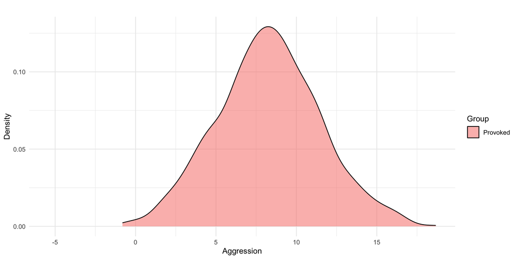

## Cohen’s d - Examples

*Are people are more aggressive toward individuals who have provoked them?*

- Cohen’s d = 1.19

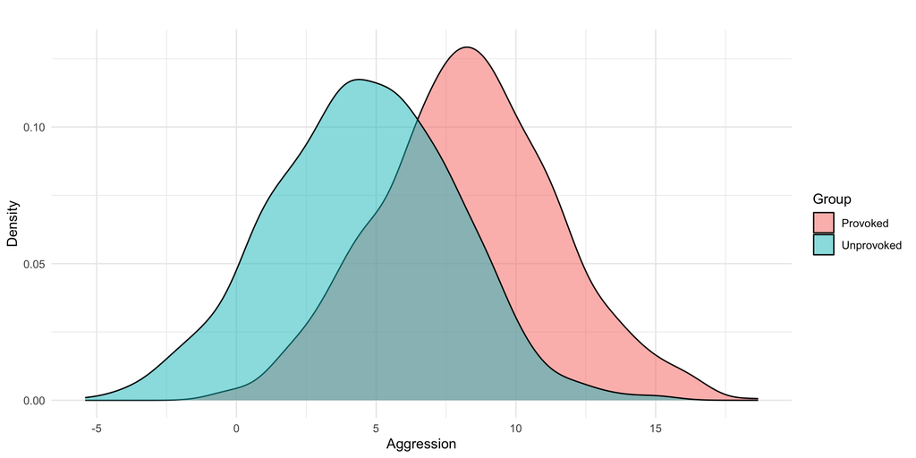

## Cohen’s d - Examples

*Are people who are seen as more credible are also more persuasive?*

- $M_{Credible}$ = 5.42/10
- $M_{Not}$ = 4.76/10
- $SD_{Persuasion}$ = 3.29
- Cohen’s d?
  - .20

## Cohen’s d - Examples

*Are people who are seen as more credible are also more persuasive?*

- Cohen’s d = .20

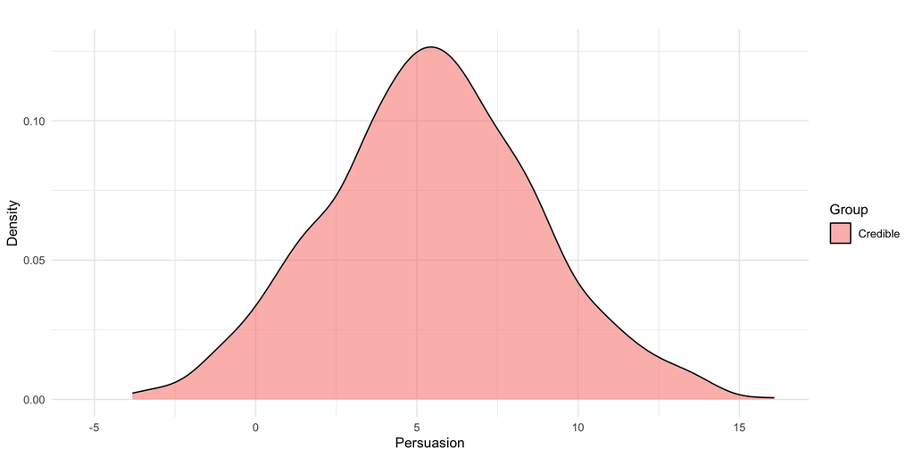

## Cohen’s d - Examples

*Are people who are seen as more credible are also more persuasive?*

- Cohen’s d = .20

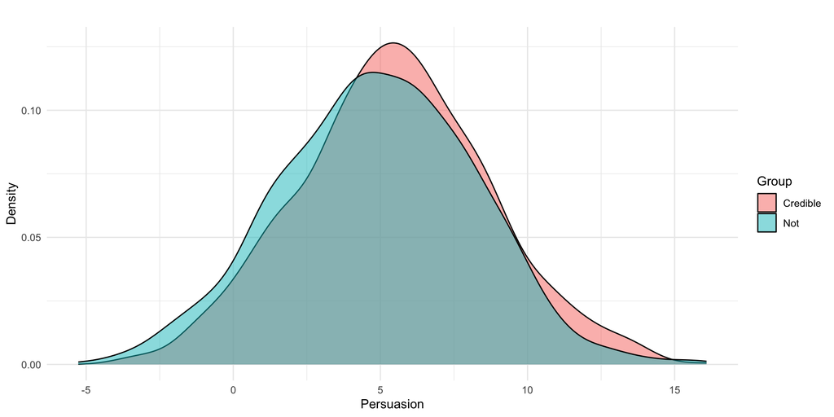

## Contextualize your effect sizes

Sometimes you can look to other research

- Or benchmarks like the things above

Sometimes you cannot

- One good comparison is **covariates**

## Contextualizing with covariates

*Hypothesis:* Mode of ordering (smartphone vs. desktop) will influence people’s portion choices

$Portion Size = \beta_{Device}xDevice + \beta_{Hunger}Hunger + \beta_{Dieting}Dieting$

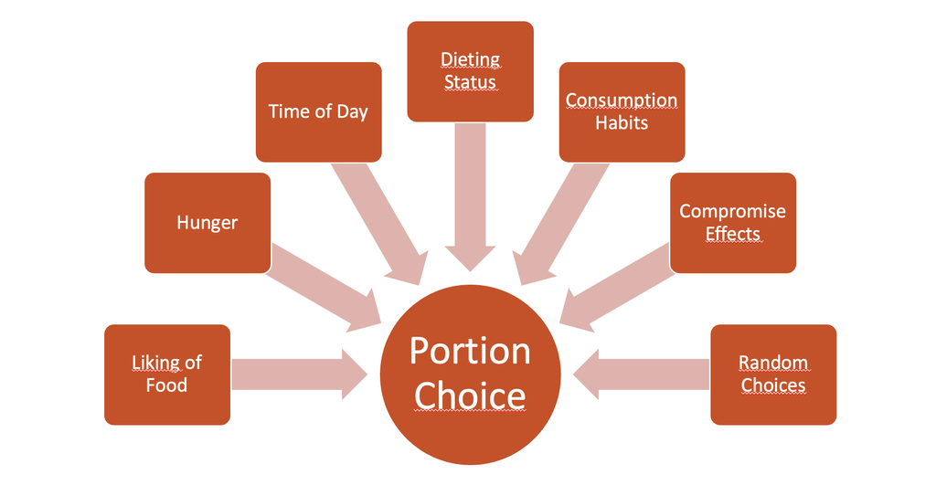

## Contextualizing with covariates

*Hypothesis:* Mode of ordering (smartphone vs. desktop) will influence people’s portion choices

$Portion Size = \beta_{Device}xDevice + \beta_{Hunger}Hunger + \beta_{Dieting}Dieting$

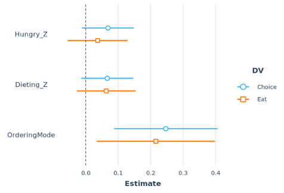

…And use common sense…

## R-Squared

$1 - \frac{SSR}{n - p - 1} \div \frac{SST}{n - 1}$

This tells you:

- For an entire model, how much of **all** of the variance you are explaining
  - We get this result from `lm()`
- For each individual effect, how much of **all** of the variance it explains
  - We can get this result from `anova()`

## R-Squared

From `anova()`

```r
customerData <- read.csv('customerData.csv')

m_1 <- lm( data = customerData, sat.service ~ 1) # Just the mean
m_2 <- lm( data = customerData, sat.service ~ email) # Effect of email
m_3 <- lm( data = customerData, sat.service ~ email + income) # Effect of email and income

anova(m_1, m_2, m_3)
```

```
Analysis of Variance Table

Model 1: sat.service ~ 1
Model 2: sat.service ~ email
Model 3: sat.service ~ email + income
  Res.Df     RSS Df Sum of Sq        F  Pr(>F)
1    590 1187.70
2    589 1179.40  1      8.30   5.9544 0.01497 *
3    588  819.51  1    359.89 258.2261 < 2e-16 ***
---
Signif. codes:  0 '***' 0.001 '**' 0.01 '*' 0.05 '.' 0.1 ' ' 1
```

## R-Squared

From `anova()`

```
Analysis of Variance Table

Model 1: sat.service ~ 1
Model 2: sat.service ~ email
Model 3: sat.service ~ email + income
  Res.Df     RSS Df Sum of Sq        F  Pr(>F)
1    590 1187.70
2    589 1179.40  1      8.30   5.9544 0.01497 *
3    588  819.51  1    359.89 258.2261 < 2e-16 ***
---
Signif. codes:  0 '***' 0.001 '**' 0.01 '*' 0.05 '.' 0.1 ' ' 1
```

## R-Squared

From `lm()`

```r
summary(m_2)
```

```
Call:
lm(formula = sat.service ~ email, data = customerData)

Residuals:
    Min      1Q  Median      3Q     Max
-3.9813 -0.7347  0.0187  1.0187  4.0187

Coefficients:
            Estimate Std. Error t value Pr(>|t|)
(Intercept)  3.98131    0.09673  41.159   <2e-16 ***
emailyes    -0.24656    0.12111  -2.036   0.0422 *
---
Signif. codes:  0 '***' 0.001 '**' 0.01 '*' 0.05 '.' 0.1 ' ' 1

Residual standard error: 1.415 on 589 degrees of freedom
  (409 observations deleted due to missingness)
Multiple R-squared:  0.006987,  Adjusted R-squared:  0.005301
F-statistic: 4.144 on 1 and 589 DF,  p-value: 0.04222
```

## Effect Size Conclusion

- There are **lots** of effect size measures out there
- They are useful, in that it’s nice to contextualize our effects
- They come in two forms:
  - Standardized differences
    - These give us a standardized way to say whether the difference between groups is **big**
  - Variance explained
    - These tell us whether some variable explains **a lot** or **a little** of our DV